# DS400: Assignment II (Python)

##### Mohamed Elsherif (Student ID: 6378374)

##### November 25, 2024

## Data Import and Description

1. Use relative paths to load the data.

```python
# Library Setup
import os
from pathlib import Path
import pandas as pd
import matplotlib.pyplot as plt
import seaborn as sns
```

```python
# Set working directory to location where this notebook is located
os.chdir(Path().resolve())

# Verify
print("My Current Working Directory: ", os.getcwd())
```

```
My Current Working Directory:  C:\Users\Admin\Downloads\DS400_W24\Assignment02
```

2. Load the data athletes and medals data into your environment. Print the first 10 observations in each dataset. Also print all variable names for each dataset.

```python
Athletes = pd.read_csv("./data/athletes.csv")
Medals = pd.read_csv("./data/medals.csv")

# Show first ten rows of datases and variables
print(Athletes.head(10))
print(Athletes.columns.tolist())

print(Medals.head(10))
print(Medals.columns.tolist())
```

```
      code                      name       name_short  \
0  1532872          ALEKSANYAN Artur     ALEKSANYAN A
1  1532873            AMOYAN Malkhas         AMOYAN M
2  1532874           GALSTYAN Slavik       GALSTYAN S
3  1532944         HARUTYUNYAN Arsen    HARUTYUNYAN A
4  1532945           TEVANYAN Vazgen       TEVANYAN V
5  1532951             ARENAS Lorena         ARENAS L
6  1533112           McKENZIE Ashley       McKENZIE A
7  1533136  BASS BITTAYE Gina Mariam  BASS BITTAYE GM
8  1533176           CAMARA Ebrahima         CAMARA E
9  1533188       RUEDA SANTOS Lizeth   RUEDA SANTOS L

                    name_tv  gender function country_code   country  \
0          Artur ALEKSANYAN    Male  Athlete          ARM   Armenia
1            Malkhas AMOYAN    Male  Athlete          ARM   Armenia
```

[output cut: 179 more lines]

3. How many different nationalities are there in the athletes dataset?

```python
# Drop NaN values first so that NaN is not counted as one of the countires, then get the unique nationalities
unique_nationalities = Athletes['nationality'].dropna().unique()
print(f"Unique nationalities ({len(unique_nationalities)}):")
```

```
Unique nationalities (197):
```

## Data Visualization

4. Create a barplot showing the number of athletes per nationality (from highest to lowest). What is wrong with this plot?

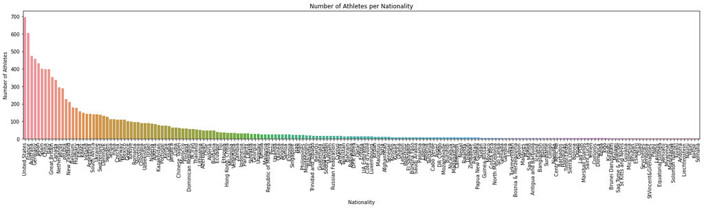

```python
# Count the number of athletes per nationality
nationality_counts = Athletes['nationality'].value_counts()

# Plot the barplot
plt.figure(figsize=(20, 6))
sns.barplot(
    x=nationality_counts.index,
    y=nationality_counts.values,
    order=nationality_counts.index[:],
)
plt.xticks(rotation=90)
plt.xlabel('Nationality')
plt.ylabel('Number of Athletes')
plt.title('Number of Athletes per Nationality')
plt.tight_layout()
plt.show()
```

The barplot has several issues: a large number of categories can clutter the x-axis, especially if NaN or empty nationalities are not filtered out, and the dominance of a few nationalities may overshadow less-represented ones, making them nearly invisible. Additionally, displaying all categories can lead to a top-heavy visualization that lacks meaningful comparison.

5. Make another barplot where only the most common nationalities are displayed (defined as having at least 100 athletes at the Olympics). The remaining athletes should be grouped into a “other” bar. Include the actual number of athletes in each bar.

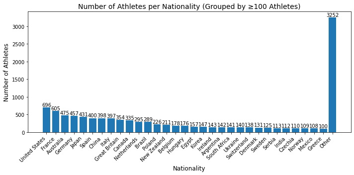

```python
# Filter nationalities with at least 100 athletes
common_nationalities = nationality_counts[nationality_counts >= 100]
other = nationality_counts[nationality_counts < 100].sum()

# Create a new series with "Other" grouped
filtered_nationalities = pd.concat([common_nationalities, pd.Series({'Other': other})])

# plot
plt.figure(figsize=(10, 5))
bars = plt.bar(filtered_nationalities.index, filtered_nationalities.values)

# Add counts
for bar in bars:
    height = bar.get_height()
    plt.text(bar.get_x() + bar.get_width() / 2, height, str(int(height)),
             ha='center', va='bottom', fontsize=10)

plt.title("Number of Athletes per Nationality (Grouped by ≥100 Athletes)", fontsize=14)
plt.xlabel("Nationality", fontsize=12)
plt.ylabel("Number of Athletes", fontsize=12)
plt.xticks(rotation=45, ha='right', fontsize=10)
plt.tight_layout()
plt.show()
```

6. Using the medals dataset, select the top 5 countries with the most medals. Create a plot showing the number of medals on the y-axis and the countries on the x-axis. Color the bars per gender. To make the plot easier to read, include only athletes that identify themselves as male or female. Use a colorblind-friendly palette

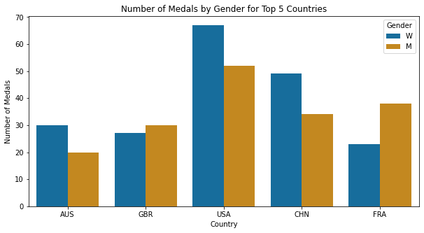

```python
# Filter medals dataset to include only male and female athletes
medals_filtered = Medals[Medals['gender'].isin(['M', 'W'])]

# Calculate the top 5 countries with the most medals
top_countries = (
    medals_filtered.groupby('country_code')
    .size()
    .nlargest(5)
    .index
)

# Filter dataset for the top 5 countries
top_medals = medals_filtered[medals_filtered['country_code'].isin(top_countries)]

# plot
plt.figure(figsize=(10, 5))
sns.barplot(
    data=top_medals,
    x='country_code',
    y='medal_code',
    hue='gender',
    palette="colorblind",
    estimator=len,
    #errorbar=None
)
plt.title("Number of Medals by Gender for Top 5 Countries")
plt.xlabel("Country")
plt.ylabel("Number of Medals")
plt.legend(title="Gender")
plt.show()
```

7. Re-create the previous plot but facet by medal type. Are there any differences between the medal types?

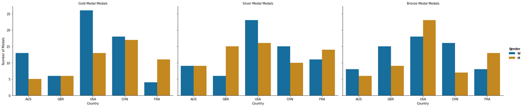

```python
# Facet the plot by medal type
g = sns.catplot(
    data=top_medals,
    x='country_code',
    hue='gender',
    col='medal_type',
    kind='count',
    palette="colorblind",
    #errorbar=None,
    height=5,
    aspect=1.5
)

g.set_titles("{col_name} Medals")
g.set_axis_labels("Country", "Number of Medals")
g.add_legend(title="Gender")
plt.show()
```

8. Create a plot that shows the cumulative medals won by the top 3 country over time?

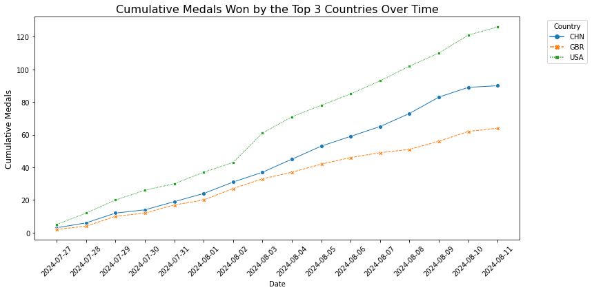

```python
# Ensure the medal_date column is in datetime format
Medals['medal_date'] = pd.to_datetime(Medals['medal_date'])

# Summarize the total number of medals per country
medals_summary = Medals[~Medals['country_code'].isna()] \
    .groupby('country_code') \
    .size() \
    .reset_index(name='total_medals') \
    .sort_values(by='total_medals', ascending=False)

# Select the top 3 countries
top_3_countries = medals_summary['country_code'].head(3)

# Filter the medals dataset for the top 3 countries
medals_top_3 = Medals[Medals['country_code'].isin(top_3_countries) & ~Medals['medal_date'].isna()]

# Calculate daily medal counts and cumulative medals
medals_cumulative = medals_top_3.groupby(['country_code', 'medal_date']) \
    .size() \
    .reset_index(name='daily_medals') \
    .sort_values(by='medal_date')

# Add cumulative medals column
medals_cumulative['cumulative_medals'] = medals_cumulative.groupby('country_code')['daily_medals'].cumsum()

# plot
plt.figure(figsize=(12, 6))
sns.lineplot(
    data=medals_cumulative,
    x='medal_date',
    y='cumulative_medals',
    hue='country_code',
    style='country_code',
    markers=True,
    linewidth=1
)


plt.title('Cumulative Medals Won by the Top 3 Countries Over Time', fontsize=16)
plt.xticks(rotation=45)
plt.xlabel('Date', fontsize=10)
plt.ylabel('Cumulative Medals', fontsize=12)
plt.xticks(medals_cumulative['medal_date'].unique(), rotation=45)

plt.legend(title='Country', bbox_to_anchor=(1.05, 1), loc='upper left')
plt.grid(False)
plt.tight_layout()
plt.show()
```

9. Import the athletics dataset (discipline_athletics.csv). Keep only the data from women’s and men’s 100m and 200m finals. Print the dimensions of the resulting dataset.

```python
DdisciplineAthletics = pd.read_csv("./data/discipline_athletics.csv")

MW_100200 = DdisciplineAthletics[
    (DdisciplineAthletics['event_code'].isin(['ATHM100M', 'ATHM200M', 'ATHW100M', 'ATHW200M'])) &
    (DdisciplineAthletics['stage'] == 'Final') &
    (DdisciplineAthletics['gender'].isin(['M', 'W']))
]

print(f"Dimensions of the filtered dataset: {MW_100200.shape}")
```

```
Dimensions of the filtered dataset: (32, 24)
```

10. Create two plots (side-by-side) that shows the distribution of the athletes’ ages and their finish time, once for the 100m final and once for the 200m final. Color the athletes by their gender. Do not use a shared axes for the two plots. What can you observe from the plots?

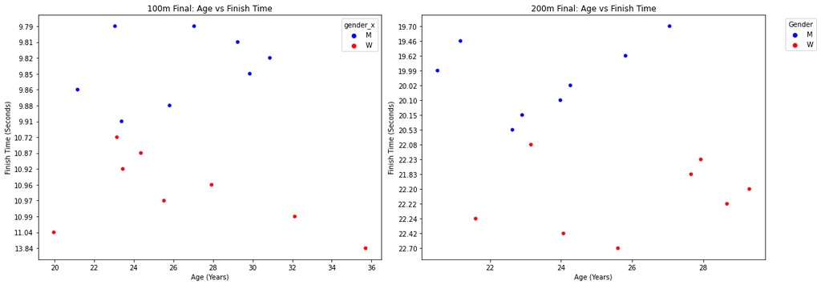

```python
# Convert participant_code and code to string type for consistent merging
MW_100200['participant_code'] = MW_100200['participant_code'].astype(str)
Athletes['code'] = Athletes['code'].astype(str)

# Merge MW_100200 with Athletes dataset
merged_data = MW_100200.merge(Athletes, left_on='participant_code', right_on='code', how='inner')

# Convert date columns to datetime format and remove time information
merged_data['date'] = pd.to_datetime(merged_data['date']).dt.tz_localize(None)
merged_data['birth_date'] = pd.to_datetime(merged_data['birth_date']).dt.tz_localize(None)

# Calculate athletes' ages
merged_data['age'] = (merged_data['date'] - merged_data['birth_date']).dt.days / 365.25

# Filter the dataset for 100m and 200m events
data_100m = merged_data[merged_data['event_code'].str.contains('ATHM100M|ATHW100M')]
data_200m = merged_data[merged_data['event_code'].str.contains('ATHM200M|ATHW200M')]


fig, axes = plt.subplots(1, 2, figsize=(16, 6), sharey=False)
# Plot for 100m event
sns.scatterplot(
    ax=axes[0],
    data=data_100m,
    x='age',
    y='result',
    hue='gender_x',
    palette={'M': 'blue', 'W': 'red'}
)
axes[0].set_title('100m Final: Age vs Finish Time')
axes[0].set_xlabel('Age (Years)')
axes[0].set_ylabel('Finish Time (Seconds)')

# Plot for 200m event
sns.scatterplot(
    ax=axes[1],
    data=data_200m,
    x='age',
    y='result',
    hue='gender_x',
    palette={'M': 'blue', 'W': 'red'}
)
axes[1].set_title('200m Final: Age vs Finish Time')
axes[1].set_xlabel('Age (Years)')
axes[1].set_ylabel('Finish Time (Seconds)')
fig.tight_layout()
plt.legend(title='Gender', bbox_to_anchor=(1.05, 1), loc='upper left')
plt.show()
```

### SQL

11. Print the names of all tables in the database.

```python
import sqlite3

# Connect to database
db_path = "./data/imdb.db"
conn = sqlite3.connect(db_path)

# list all tables in the database
query = "SELECT name FROM sqlite_master WHERE type='table';"

# Execute query
tables = pd.read_sql(query, conn).values

print("Tables in the IMDb database:")
print(tables)
```

```
Tables in the IMDb database:
[['ratings']
 ['names']
 ['titles']]
```

12. Print the first 10 rows of the names table.

```python
# retrieve the first 10 rows of the 'names' table
query_names = "SELECT * FROM names LIMIT 10;"

# Execute query
names_table = pd.read_sql(query_names, conn)

print("First 10 rows of the 'names' table:")
print(names_table)
```

```
First 10 rows of the 'names' table:
       nconst           primaryName birthYear deathYear  \
0   nm2022849            Liz Fuller      None      None
1  nm14917090  Nadine Kurkchubasche      None      None
2   nm9059617            Greg Smith      None      None
3   nm2649914           Farah Fayed      None      None
4   nm1968586           Maureen Fry      None      None
5   nm7408054          Hagar Scherf      None      None
6  nm16080814            Zack Smith      None      None
7  nm10665585           Indy Miller      None      None
8   nm4353414     Richard T. Gordon      None      None
9  nm14455950       Takuya Tanimura      None      None

                   primaryProfession                           knownForTitles
0  manager,casting_director,producer  tt2175470,tt3014478,tt5190038,tt2847592
1                               None                                     None
2                  camera_department                                tt6819682
3                             editor  tt1029243,tt2526130,tt2870870,tt3461578
4                            actress                                tt0148583
5                 assistant_director                                tt4777584
6                               None                               tt26342131
7                               None                                     None
8                               None                                     None
9                              actor                                tt0433499
```

13. How many unique names exist in the names table?

```python
# count unique names in the 'names' table
query_unique_names = "SELECT COUNT(DISTINCT primaryName) AS unique_name_count FROM names WHERE primaryName IS NOT NULL;"

# Execute query
unique_names_count = pd.read_sql(query_unique_names, conn)

print("Number of unique names in the 'names' table:")
print(unique_names_count)
```

```
Number of unique names in the 'names' table:
   unique_name_count
0              98487
```

14. What is the average rating of all titles in the ratings table?

```python
# Find columns names in 'rating' table
ratings_columns = pd.read_sql("PRAGMA table_info(ratings);", conn)
print("Columns in the 'ratings' table:")
print(ratings_columns)

# calculate the average rating
query_avg_rating = "SELECT AVG(averageRating) AS avg_rating FROM ratings;"

# Execute query
avg_rating = pd.read_sql(query_avg_rating, conn)

print("The average rating of all titles in the ratings table:")
print(avg_rating)
```

```
Columns in the 'ratings' table:
   cid           name     type  notnull dflt_value  pk
0    0         tconst     TEXT        0       None   0
1    1  averageRating     REAL        0       None   0
2    2       numVotes  INTEGER        0       None   0
The average rating of all titles in the ratings table:
   avg_rating
0    6.957862
```

15. What is the average rating of all titles in the ratings table that have less than 100 votes?

```python
# calculate the average rating for titles with less than 100 votes
query_avg_rating_100_votes = """
SELECT AVG(averageRating) AS avg_rating
FROM ratings
WHERE numVotes < 100;
"""
# Execute query
avg_rating_100_votes = pd.read_sql(query_avg_rating_100_votes, conn)

print("The average rating of titles with less than 100 votes:")
print(avg_rating_100_votes)
```

```
The average rating of titles with less than 100 votes:
   avg_rating
0    7.008584
```

16. List the names, birth years, and primary professions of the 10 oldest actors/actresses in the database.

```python
# find the 10 oldest actors/actresses, excluding missing birthYear values
query_oldest_actors = """
SELECT primaryName, birthYear, primaryProfession
FROM names
WHERE (primaryProfession LIKE '%actor%' OR primaryProfession LIKE '%actress%')
AND birthYear IS NOT NULL
ORDER BY birthYear ASC
LIMIT 10;
"""

# Execute query
oldest_actors = pd.read_sql(query_oldest_actors, conn)

print("The 10 oldest actors/actresses:")
print(oldest_actors)
```

```
The 10 oldest actors/actresses:
         primaryName  birthYear        primaryProfession
0  Frederick Bernard     1848.0                    actor
1          Tom Merry     1853.0                    actor
2       Frank McNish     1853.0                    actor
3       August Kiehl     1854.0                    actor
4   Gabriela Montani     1854.0                  actress
5     Ernest Hendrie     1859.0             actor,writer
6        Edward Hoyt     1859.0                    actor
7         Peter Lang     1859.0                    actor
8         Kate Bruce     1860.0  actress,archive_footage
9  William McIllwain     1863.0                    actor
```

17. Which three movies have the lowest ratings? Print their name, release year, title type, and rating.

```python
# find the 3 movies with the lowest ratings
query_lowest_rated_movies = """
SELECT t.primaryTitle, t.startYear, t.titleType, r.averageRating
FROM titles t
JOIN ratings r ON t.tconst = r.tconst
WHERE t.titleType = 'movie'
ORDER BY r.averageRating ASC
LIMIT 3;
"""

# Execute query
lowest_rated_movies = pd.read_sql(query_lowest_rated_movies, conn)

print("The 3 movies with the lowest ratings:")
print(lowest_rated_movies)
```

```
The 3 movies with the lowest ratings:
              primaryTitle  startYear titleType  averageRating
0               Robot Wars     2016.0     movie            2.4
1       Silencio de muerte     1991.0     movie            2.8
2  Strippers vs Werewolves     2012.0     movie            3.0
```

18. Create a histogram plot that shows the distribution of TV series ratings vs. movie ratings. What can you observe from the plot?

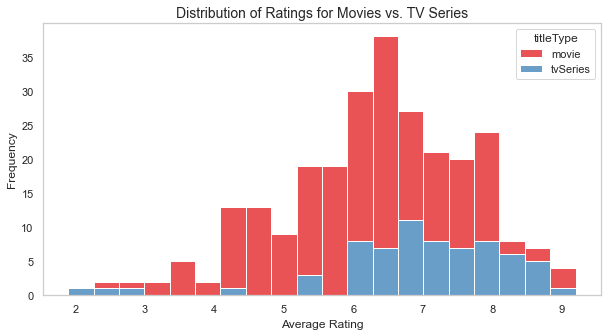

```python
# get the ratings of TV series and movies
query_ratings_distribution = """
SELECT t.titleType, r.averageRating
FROM titles t
JOIN ratings r ON t.tconst = r.tconst
WHERE t.titleType IN ('movie', 'tvSeries');
"""
# Execute query
ratings_data = pd.read_sql(query_ratings_distribution, conn)

# histogram for movie and TV series ratings
sns.set(style="whitegrid")
plt.figure(figsize=(10, 5))
sns.histplot(data=ratings_data, x="averageRating", hue="titleType", multiple="stack", bins=20, kde=False, palette="Set1")
plt.title("Distribution of Ratings for Movies vs. TV Series", fontsize=14)
plt.xlabel("Average Rating", fontsize=12)
plt.ylabel("Frequency", fontsize=12)
plt.grid(False)
plt.show()
```

**TV Series** are generally rated higher than movies, with more frequent ratings above 7 and fewer very low ratings. On the other hand **Movies** have a wider distribution of ratings, from extremely low to very high. There also seem to be extreme outliers on both ends for both movies and TV series. Some titles have ratings as low as 1.9 (TV series), and others as high as 9.2 (movies), indicating that both genres have extremes in viewer reception.

19. Close the connection to the database (if applicable).

Closing connection is not required here as this is done automatically in python.